# Analisis inferencial: Regresion lineal

Anthony J. Servita R.

16/10/2020

Entendimiento del problema: datos representan el diseño de plantas en climas dificiles.

1.- Conocimiento de los datos

```r
options(digits = 2)
Duracion <- c(92, 92, 96, 100, 102, 102, 106, 106, 121, 143)
Rendimiento <- c(1.7, 2.3, 1.9, 2, 1.5, 1.7, 1.6, 1.8, 1, 0.3)
datasets <- data.frame(Duracion, Rendimiento)
head(datasets)
```

```
##   Duracion Rendimiento
## 1       92         1.7
## 2       92         2.3
## 3       96         1.9
## 4      100         2.0
## 5      102         1.5
## 6      102         1.7
```

Regresión lineal:

```r
## correlación
df <- datasets
df %>%
  select_if(is.double) %>%
  cor() %>%
  round(digits = 2)
```

```
##             Duracion Rendimiento
## Duracion        1.00       -0.94
## Rendimiento    -0.94        1.00
```

ambas variables presentan una correlacion muy alta y significativa de forma negativa

ecuación de la recta:

```r
regresion <- lm(Rendimiento ~ Duracion, df)
regresion
```

```
##
## Call:
## lm(formula = Rendimiento ~ Duracion, data = df)
##
## Coefficients:
## (Intercept)     Duracion
##      5.2068      -0.0342
```

la ecuación de la recta esta dada por Y = mx + b sus valores son: y = -0.0342x + 5.2068

```r
summary(regresion)
```

```
##
## Call:
## lm(formula = Rendimiento ~ Duracion, data = df)
##
## Residuals:
##     Min      1Q  Median      3Q     Max
## -0.3590 -0.0556 -0.0154  0.1660  0.2410
##
## Coefficients:
##             Estimate Std. Error t value Pr(>|t|)
## (Intercept)   5.2068     0.4713   11.05  4.0e-06 ***
## Duracion     -0.0342     0.0044   -7.77  5.4e-05 ***
## ---
## Signif. codes:  0 '***' 0.001 '**' 0.01 '*' 0.05 '.' 0.1 ' ' 1
##
## Residual standard error: 0.2 on 8 degrees of freedom
## Multiple R-squared:  0.883,  Adjusted R-squared:  0.868
## F-statistic: 60.3 on 1 and 8 DF,  p-value: 5.39e-05
```

el valor de p es muy significativo ***. por lo que existe una regresion lineal significativa entre la duracion y el rendimiento.

Estimación del rendimiento:

```r
newdata <- c(104)
predict(regresion, newdata = data.frame(Duracion = c(104)),
        interval ="prediction", level = 0.95)
```

```
##   fit lwr upr
## 1 1.6 1.2 2.1
```

el valor fit se encuentra dentro del intervalor lwr y upr por lo que se tiene un 95% de confianza de que el valor esperado para la “Duracion” de una planta en climas dificiles es de 1.6 de “Rendimiento”.

Gráfica de regresion.

```r
attach(df)
```

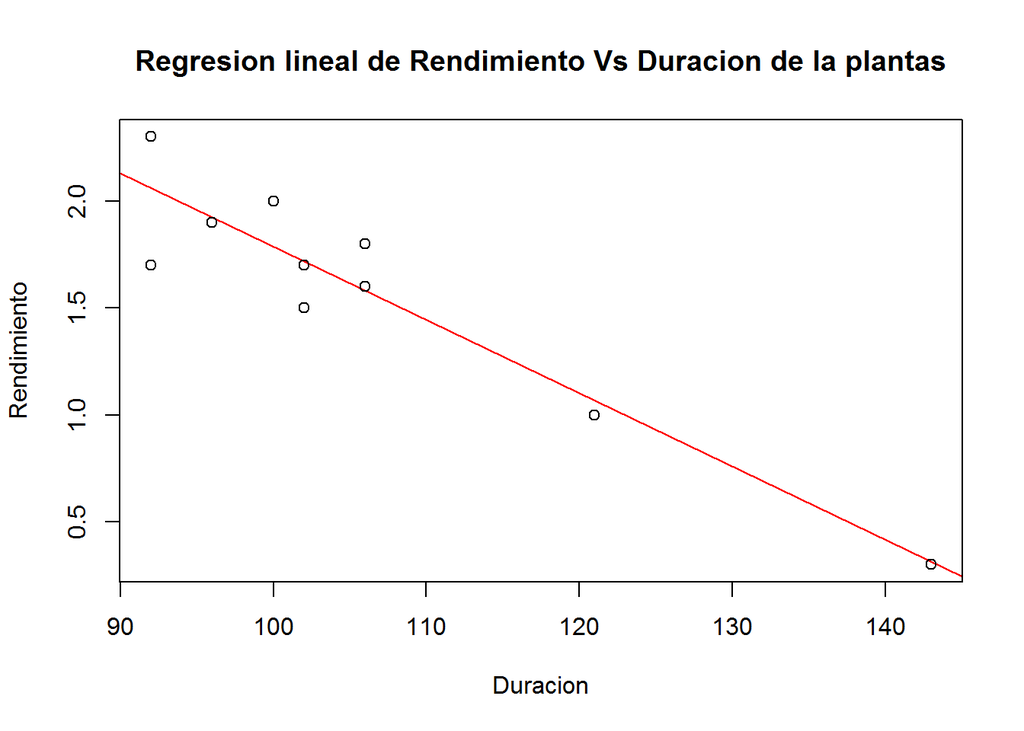

```r
plot(Duracion, Rendimiento, abline(regresion, col = "red"),
     main = "Regresion lineal de Rendimiento Vs Duracion de la plantas")
```

La recta calculada en la regresion lineal se ajusta muy bien a los datos dispersos en las variables rendimiento y duracion.